# Overview for mand

2026-09-13 @Atsushi Kawaguchi

The `mand` package provides functions for multivariate analysis for neuroimaging data.

```r
library(mand)
library(msma)
```

# Introduction

## Template

One subject image as the template is available in the mand package. The coad to load it is as follows.

```r
data(template)
```

The image is compressed because of storage and computation time. The dimension is confirmed as follows.

```r
dim(template)
```

```
## [1] 30 36 30
```

The image is plotted by the `coat` function.

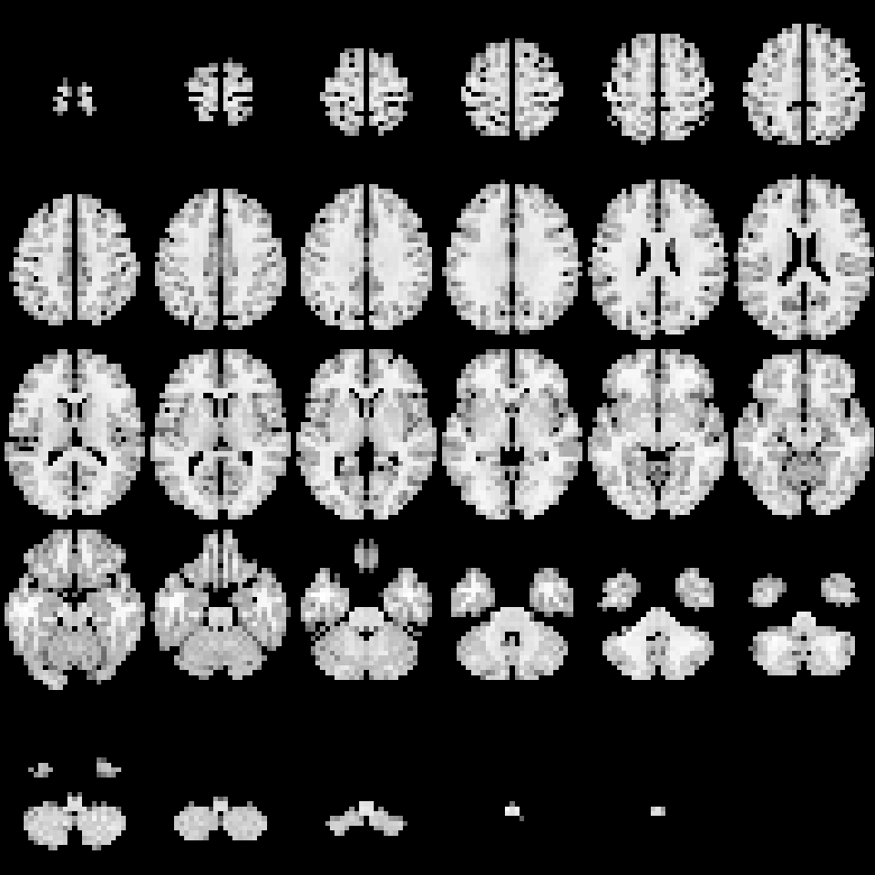

```r
coat(template)
```

Other options with the plane argument (such as “axial,” “coronal,” “sagittal,” and “all”) are available. The default setting is “axial”. If the argument is specified as `plane="all"`, three directional slices at a certain coordinate are plotted.

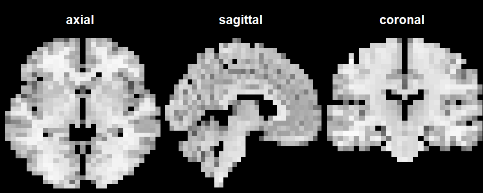

```r
coat(x=template, plane="all")
```

## Image Data Matrix

The `imgdatamat` function reads image files saved in the nifti format and creates data matrix with subjects in row and voxel in column (this example does not work).

```r
fnames1 = c("data1.nii", "data2.nii")
imgmat = imgdatamat(fnames1, simscale=1/4)
```

The first argument is file names with the length equaling the number of subjects (the number of rows in the resulting data matrix). The second argument `simscale` is the image resize scale. In this example, the all sizes (number of voxel) for three direction was reduced into its quarter size. The output is the list form where the “S” is data matrix, the “brainpos” is a binary image indicating brain region, and the “imagedim” is image dimension. The ROI (Region Of Interest) volume is computed in the “roi” if the ROI argument is TRUE.

```r
imgmat = imgdatamat(fnames1, schange=TRUE, simscale=1/4, ROI=TRUE)
```

## Overlay

The resulting map from the statistical analysis such as the t statistics map from the SPM is represented with overlapping on the template. For example, the `mand` package has the average difference assuming Alzheimer’s disease and healthy subjects with the array format.

The overlay is implemented by the `coat` function.

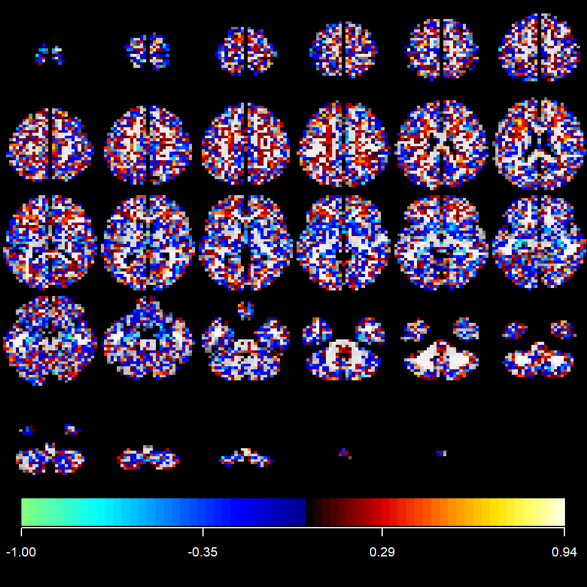

```r
data(diffimg)
coat(template, diffimg)
```

## Atlas

Anatomical brain segmentation region is useful for the plot and the interpretation. For example, the Automated Anatomical Labeling (AAL) atlas is used. The data.frame has two columns (“ROIid” and “ROIname”) format.

```r
data(atlasdatasets)
atlasname = "aal3"
atlasdataset = atlasdatasets[[atlasname]]
head(atlasdataset)
```

```
##   ROIid                                   ROIname
## 1     1                     Left Precentral gyrus
## 2     2                    Right Precentral gyrus
## 3     3  Left Superior frontal gyrus-dorsolateral
## 4     4 Right Superior frontal gyrus-dorsolateral
## 5     5                 Left Middle frontal gyrus
## 6     6                Right Middle frontal gyrus
```

It is also neccesary to prepare the array data.

```r
data(atlas)
tmpatlas = atlas[[atlasname]]
dim(tmpatlas)
```

```
## [1] 30 36 30
```

It has the ROIid as the element.

```r
tmpatlas[,15:20,12]
```

```
##       [,1] [,2] [,3] [,4] [,5] [,6]
##  [1,]    0    0    0    0    0    0
##  [2,]    0    0    0    0    0    0
##  [3,]   90   90   90   90   90   90
##  [4,]   94   94   90   90   90   90
##  [5,]   94   94   90   90   90   90
##  [6,]   94   90   90   90   90   90
##  [7,]   94    0    0    0   90   90
##  [8,]    0    0    0    0    0    0
##  [9,]   60   44   42   42   42    0
## [10,]   60   44   42   42   42   42
## [11,]   44   44   42   42   42   42
## [12,]   44   44   44    0    0   42
## [13,]   52    0    0    0    0    0
## [14,]  100    0    0  162  162  164
```

[output cut: 16 more lines]

The anatomical region can be plotted by the `coat` function with regionplot=TRUE.

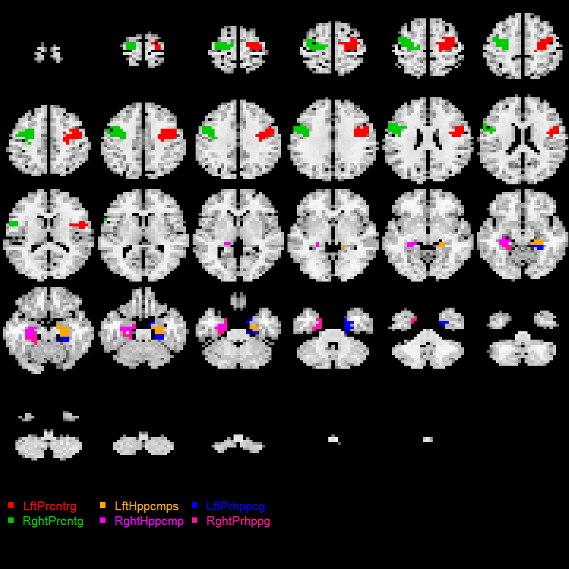

```r
coat(template, tmpatlas, regionplot=TRUE,
atlasdataset=atlasdataset, ROIids = c(1:2, 41:44), regionlegend=TRUE)
```

The resulting map can be converted into the summary of the anatomical regions.

```r
atlastable(tmpatlas, diffimg, atlasdataset, ROIids = c(1:2, 41:44))
```

```
## $table
##    ROIid                     ROIname sizenum   sizepct    sumvalue       Min. 1st Qu. Median          Mean 3rd Qu.      Max.
## 1      1       Left Precentral gyrus     116 0.6170213   8.2999981 -0.5675001       0      0  2.561728e-04       0 0.8024999
## 2      2      Right Precentral gyrus     115 0.6318681  -0.3050001 -0.7349999       0      0 -9.413584e-06       0 0.7499998
## 41    41            Left Hippocampus      26 0.5909091  -7.1899993 -1.0000000       0      0 -2.219136e-04       0 0.4475000
## 42    42           Right Hippocampus      33 0.7333333 -12.1099996 -0.9675000       0      0 -3.737654e-04       0 0.5049999
## 43    43  Left Parahippocampal gyrus      30 0.7317073  -5.4949995 -0.8750000       0      0 -1.695988e-04       0 0.5300001
## 44    44 Right Parahippocampal gyrus      27 0.6923077  -3.1474993 -0.7500000       0      0 -9.714504e-05       0 0.6899998
##
## attr(,"class")
## [1] "atlastable"
```

The brain image corresponding to the region of interest can be extracted as follows. First, we create a mask image in which the hippocampal region is represented by 1 and others by 0. Then the product of the template and the mask image is taken for each voxel.

```r
hipmask = (tmpatlas == 41) + (tmpatlas == 42)
template2 = template * hipmask
```

The images generated by these processes are plotted from left to right in one slice.

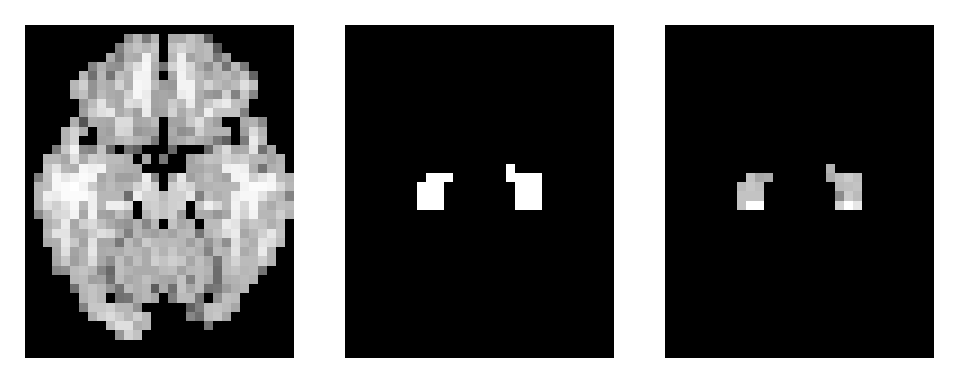

```r
par(mfrow=c(1,3), mar=rep(1,4))
coat(template, pseq=12, paron=FALSE)
coat(hipmask, pseq=12, paron=FALSE)
coat(template2, pseq=12, paron=FALSE)
```

The template image (left) and the mask image (middle) are multiplied voxel by voxel to obtain the only hippocampus region image (right).

The sum of the voxel values in the region is calculated as follows.

```r
sum(template[which(hipmask==1, arr.ind = TRUE)])/1000
```

```
## [1] 0.07090703
```

Such a value is calculated for each region and a dataset with ROI values is created.

# Principal Component Analysis

## Generate Simulation Data

The `mand` package has a function to generate simulation brain data from the base image, the difference image and the standard deviation image. These basic images are loaded as follows.

```r
data(baseimg)
data(diffimg)
data(mask)
data(sdevimg)
```

The number of voxels in the original 3D image is as follows.

```r
dim(baseimg)
```

```
## [1] 30 36 30
```

To understand the result easily, the difference region was restricted to Parahippocampus and Hippocampus.

```r
diffimg2 = diffimg * (tmpatlas %in% 41:44)
```

An image data matrix with subjects in the rows and voxels in the columns was generated by using the `simbrain` function.

```r
img1 = simbrain(baseimg = baseimg, diffimg = diffimg2,
sdevimg=sdevimg, mask=mask, n0=20, c1=0.01, sd1=0.05)
```

The base image, the difference image and the standard deviation image were specified in the first three arguments. The out-of-brain region was specified by the mask argument, which was the binary image. The remaining arguments are the number of subjects per group, the coefficient multiplied by the difference image and the standard deviation for the noise.

The data matrix dimension was 40(subject) x 12620(voxel).

```r
dim(img1$S)
```

```
## [1]    40 12620
```

The `rec` function creates the 3D image from the vectorized data (the first subject).

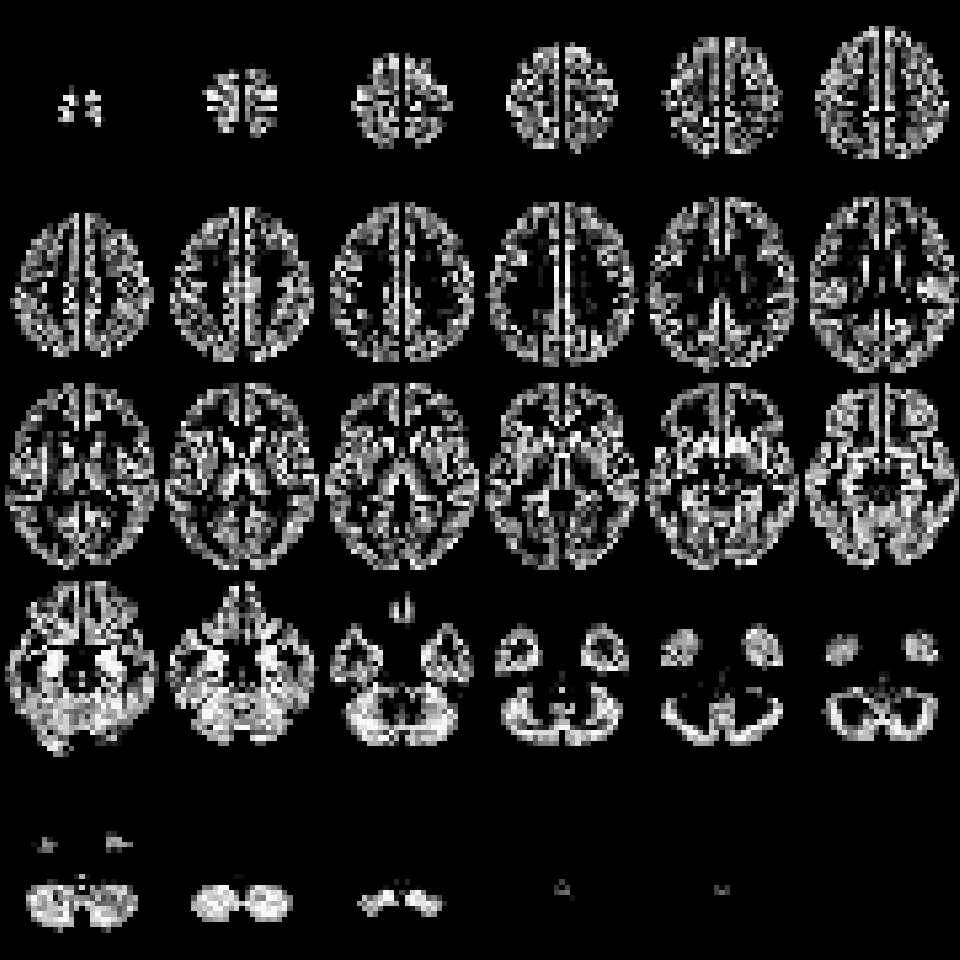

```r
coat(rec(img1$S[1,], img1$imagedim, mask=img1$brainpos))
```

The standard deviation image is created from the resulting data matrix.

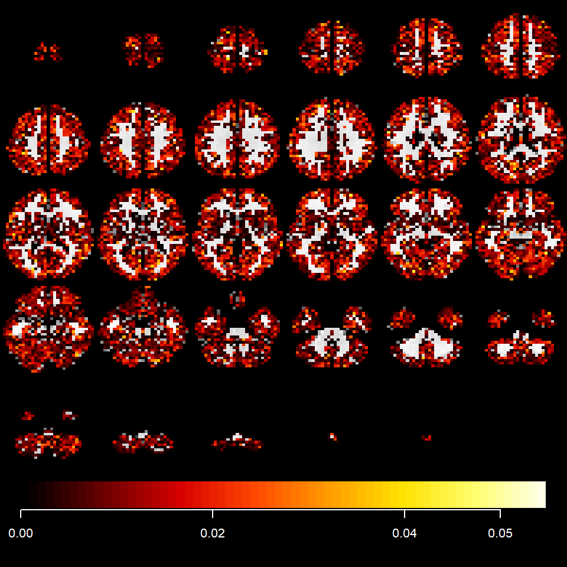

```r
sdimg = apply(img1$S, 2, sd)
coat(template, rec(sdimg, img1$imagedim, mask=img1$brainpos))
```

## Principal Component Analysis

If the input is a matrix, a principal component analysis is implemented by the `msma` function of the `msma` package. Principal component analysis with the number of components of 2 for the image data matrix is performed as follows.

```r
(fit111 = msma(img1$S, comp=2))
```

```
## Call:
## .msma_default_legacy(X = X, Y = Y, Z = Z_legacy, comp = comp,
##     lambdaX = lambdaX, lambdaY = lambdaY, lambdaXsup = lambdaXsup,
##     lambdaYsup = lambdaYsup, eta = eta, type = type, inX = inX,
##     inY = inY, inXsup = inXsup, inYsup = inYsup, muX = muX, muY = muY,
##     defmethod = defmethod, scaling = scaling, verbose = verbose,
##     intseed = intseed, ceps = ceps)
##
## Numbers of non-zeros for X block:
##        comp1 comp2
## block1  9865  9865
##
## Numbers of non-zeros for X super:
##         comp1 comp2
## comp1-1     1     1
```

The scatter plots for the score vectors specified by the argument `v`. The argument `axes` is specified by the two length vectors on which components are displayed.

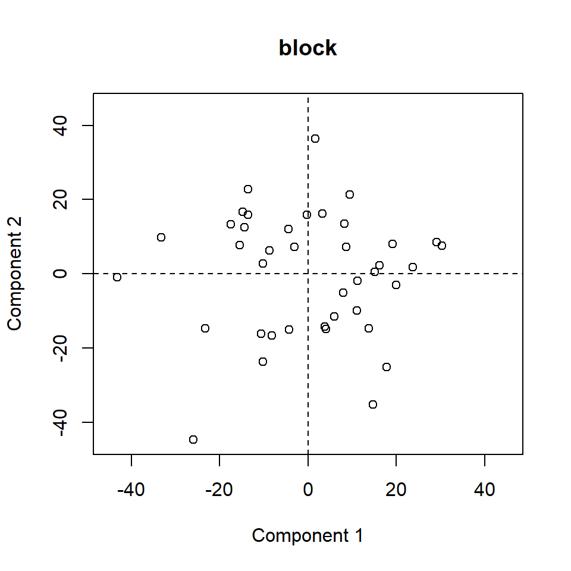

```r
plot(fit111, v="score", axes = 1:2, plottype="scatter")
```

The weight (loading) vectors can be obtained and reconstructed as follows.

```r
midx = 1 ## the index for the modality
vidx = 1 ## the index for the component
Q = fit111$wbX[[midx]][,vidx]
outstat1 = rec(Q, img1$imagedim, mask=img1$brainpos)
```

The reconstructed loadings as image is overlayed on the template.

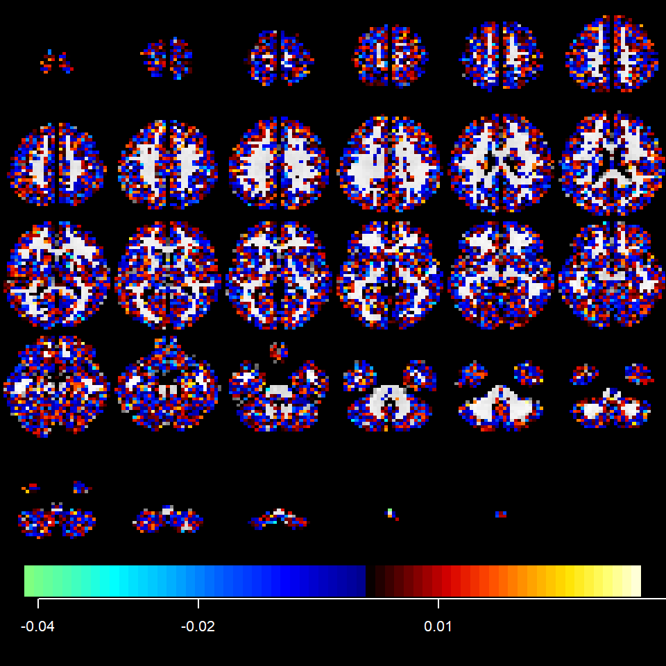

```r
coat(template, outstat1)
```

The output is unclear; however, this will be improved later.

# Two-steps dimension reduction

## Basis Expansion

This is an example of the two-step dimension reduction.

Generate radial basis function.

```r
B1 = rbfunc(imagedim=img1$imagedim, seppix=2, hispec=FALSE, mask=img1$brainpos)
```

Multiplying the basis function to image data matrix.

```r
SB1 = basisprod(img1$S, B1)
```

The original dimension was 12620.

```r
dim(img1$S)
```

```
## [1]    40 12620
```

The dimension was reduced to 1604.

```r
dim(SB1)
```

```
## [1]   40 1604
```

## Principal Component Analysis

The Principal Component Analysis (PCA) is applied to the dimension-reduced image.

```r
(fit211 = msma(SB1, comp=2))
```

```
## Call:
## .msma_default_legacy(X = X, Y = Y, Z = Z_legacy, comp = comp,
##     lambdaX = lambdaX, lambdaY = lambdaY, lambdaXsup = lambdaXsup,
##     lambdaYsup = lambdaYsup, eta = eta, type = type, inX = inX,
##     inY = inY, inXsup = inXsup, inYsup = inYsup, muX = muX, muY = muY,
##     defmethod = defmethod, scaling = scaling, verbose = verbose,
##     intseed = intseed, ceps = ceps)
##
## Numbers of non-zeros for X block:
##        comp1 comp2
## block1  1604  1604
##
## Numbers of non-zeros for X super:
##         comp1 comp2
## comp1-1     1     1
```

The loading is reconstructed to the original space by using the `rec` function.

```r
Q = fit211$wbX[[1]][,1]
outstat1 = rec(Q, img1$imagedim, B=B1, mask=img1$brainpos)
```

The plotted loading is smoother than the one without the dimension reduction by the basis function.

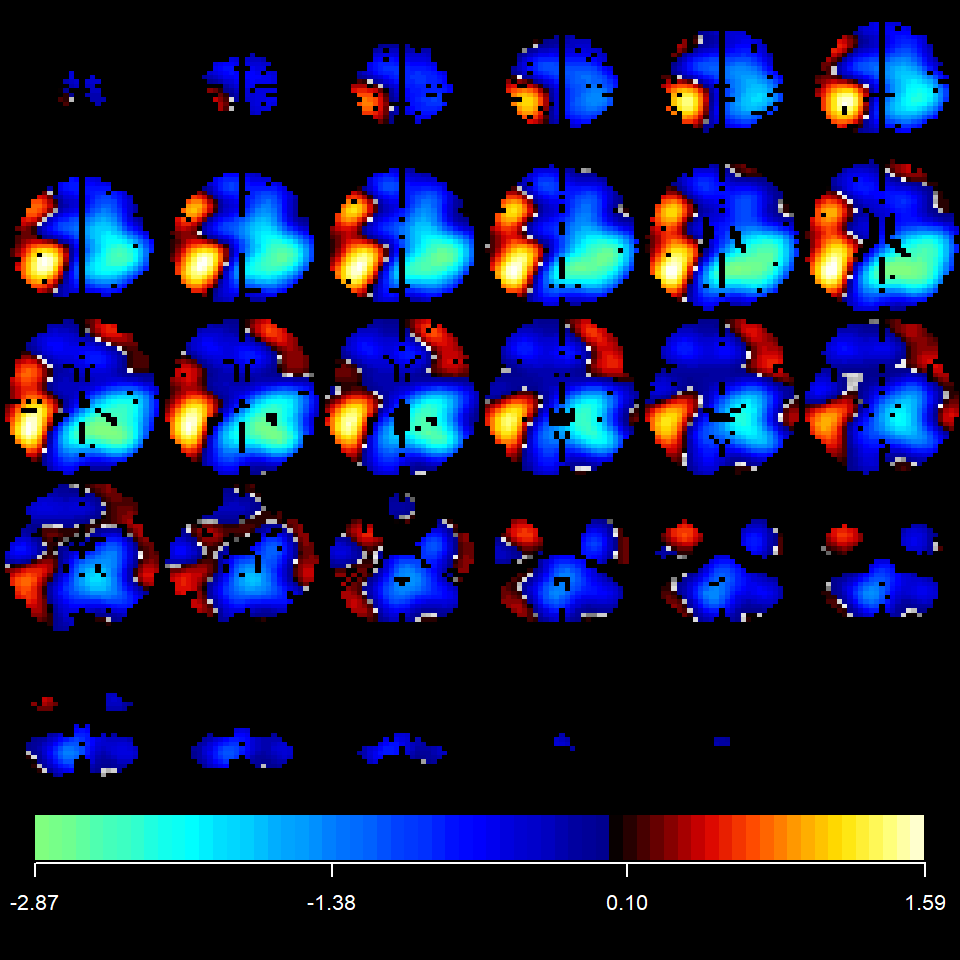

```r
coat(template, outstat1)
```

## Sparse PCA

If `lambdaX` (>0) is specified, a sparse principal component analysis is implemented.

```r
(fit112 = msma(SB1, comp=2, lambdaX=0.06))
```

```
## Call:
## .msma_default_legacy(X = X, Y = Y, Z = Z_legacy, comp = comp,
##     lambdaX = lambdaX, lambdaY = lambdaY, lambdaXsup = lambdaXsup,
##     lambdaYsup = lambdaYsup, eta = eta, type = type, inX = inX,
##     inY = inY, inXsup = inXsup, inYsup = inYsup, muX = muX, muY = muY,
##     defmethod = defmethod, scaling = scaling, verbose = verbose,
##     intseed = intseed, ceps = ceps)
##
## Numbers of non-zeros for X block:
##        comp1 comp2
## block1    53    40
##
## Numbers of non-zeros for X super:
##         comp1 comp2
## comp1-1     1     1
```

The plotted loading is narrower than that from the PCA.

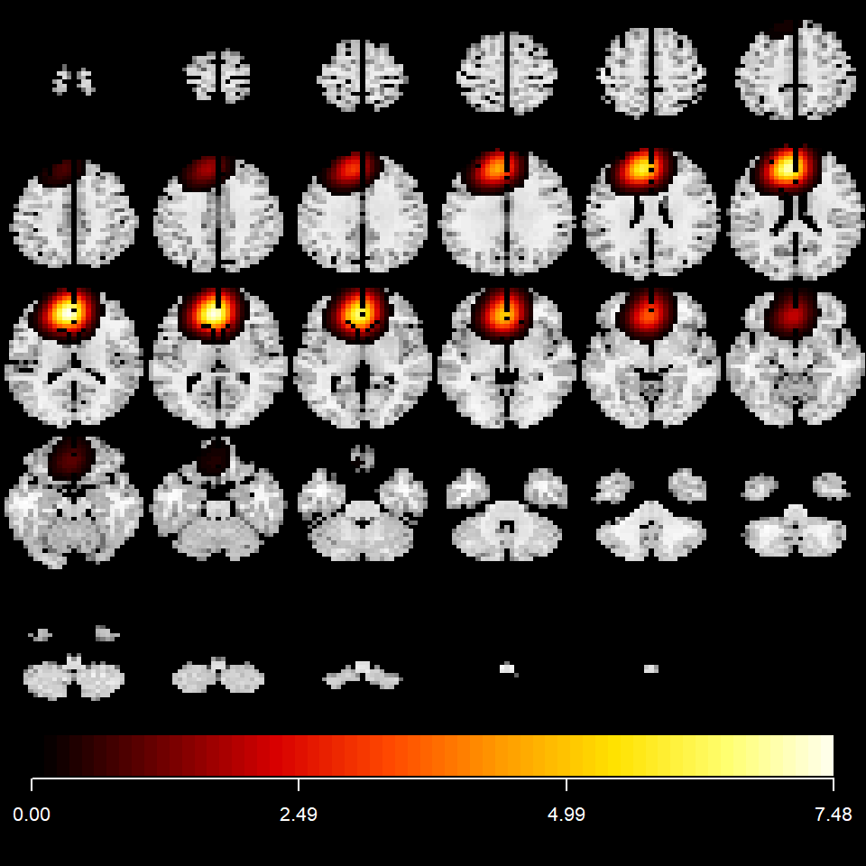

```r
Q = fit112$wbX[[midx]][,vidx]
outstat1 = rec(Q, img1$imagedim, B=B1, mask=img1$brainpos)
outstat2 = outstat1
coat(template, outstat2)
```

The region is reported as follows to be compared with the next method.

```r
atlastable(tmpatlas, outstat2, atlasdataset)
```

```
## $table
##     ROIid                                                                ROIname sizenum    sizepct     sumvalue Min. 1st Qu. Median         Mean 3rd Qu.         Max.
## 1       1                                                  Left Precentral gyrus       0 0.00000000 0.000000e+00    0       0      0 0.000000e+00       0 0.000000e+00
## 2       2                                                 Right Precentral gyrus      56 0.30769231 4.748789e-01    0       0      0 1.465676e-05       0 1.424819e-01
## 3       3                               Left Superior frontal gyrus-dorsolateral     180 0.72000000 8.552688e+01    0       0      0 2.639719e-03       0 2.332348e+00
## 4       4                              Right Superior frontal gyrus-dorsolateral     207 0.84489796 2.577099e+02    0       0      0 7.954008e-03       0 5.165228e+00
## 5       5                                              Left Middle frontal gyrus     152 0.60317460 7.292652e+00    0       0      0 2.250818e-04       0 5.065971e-01
## 6       6                                             Right Middle frontal gyrus     243 0.97590361 1.277586e+02    0       0      0 3.943165e-03       0 3.423288e+00
## 7       7                             Left Inferior frontal gyrus-opercular part       7 0.11475410 2.861414e-03    0       0      0 8.831525e-08       0 1.440939e-03
## 8       8                            Right Inferior frontal gyrus-opercular part      64 0.94117647 5.151732e+00    0       0      0 1.590041e-04       0 5.929501e-01
## 9       9                            Left Inferior frontal gyrus-triangular part      57 0.50892857 6.078731e-01    0       0      0 1.876151e-05       0 1.129497e-01
## 10     10                           Right Inferior frontal gyrus-triangular part     115 0.99137931 2.188454e+01    0       0      0 6.754489e-04       0 1.911110e+00
## 11     11                                                Left IFG pars orbitalis      21 0.58333333 4.266604e-01    0       0      0 1.316853e-05       0 1.065023e-01
## 12     12                                               Right IFG pars orbitalis      43 0.93478261 2.176215e+00    0       0      0 6.716713e-05       0 5.083335e-01
## 13     13                                                Left Rolandic operculum       0 0.00000000 0.000000e+00    0       0      0 0.000000e+00       0 0.000000e+00
```

[output cut: 160 more lines]

## Supervised Sparse PCA

The `simbrain` generates the synthetic brain image data and the binary outcome. The outcome Z is obtained.

```r
Z = img1$Z
```

If the outcome Z is specified in the `msma` function, a supervised sparse principal component analysis is implemented.

```r
(fit113 = msma(SB1, Z=Z, comp=2, lambdaX=0.06, muX=0.5))
```

```
## Call:
## .msma_default_legacy(X = X, Y = Y, Z = Z_legacy, comp = comp,
##     lambdaX = lambdaX, lambdaY = lambdaY, lambdaXsup = lambdaXsup,
##     lambdaYsup = lambdaYsup, eta = eta, type = type, inX = inX,
##     inY = inY, inXsup = inXsup, inYsup = inYsup, muX = muX, muY = muY,
##     defmethod = defmethod, scaling = scaling, verbose = verbose,
##     intseed = intseed, ceps = ceps)
##
## Numbers of non-zeros for X block:
##        comp1 comp2
## block1    48    38
##
## Numbers of non-zeros for X super:
##         comp1 comp2
## comp1-1     1     1
```

The plotted loading is located differently from the sparse PCA.

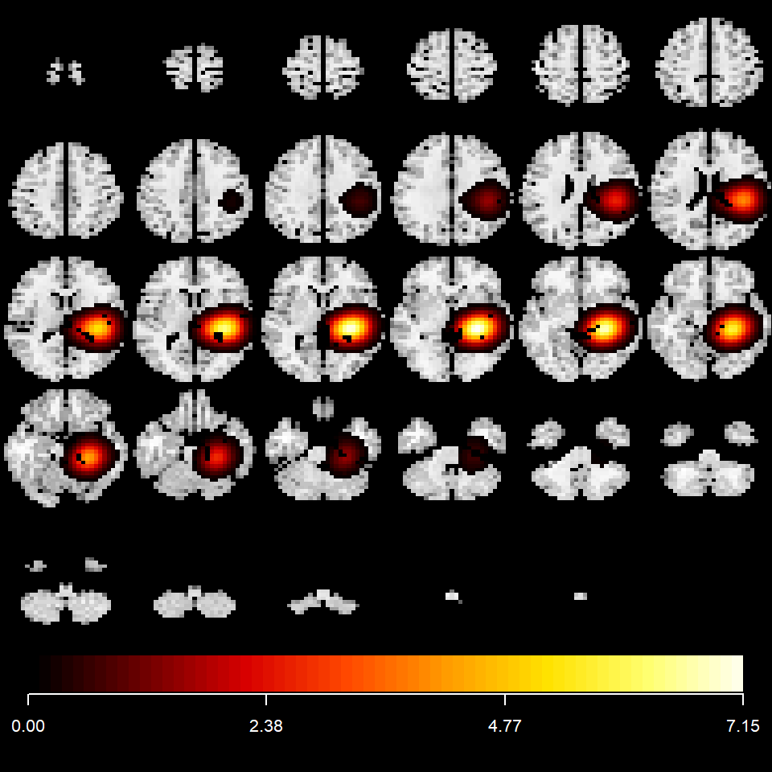

```r
Q = fit113$wbX[[1]][,1]
outstat1 = rec(Q, img1$imagedim, B=B1, mask=img1$brainpos)
outstat2 = -outstat1
coat(template, outstat2)
```

The region near the hippocampus, which differs from the sparse PCA (without supervision).

```r
atlastable(tmpatlas, outstat2, atlasdataset)
```

```
## $table
##     ROIid                                                                ROIname sizenum    sizepct     sumvalue Min. 1st Qu. Median         Mean 3rd Qu.         Max.
## 1       1                                                  Left Precentral gyrus     124 0.65957447 1.062377e+01    0       0      0 3.278941e-04       0 8.569300e-01
## 2       2                                                 Right Precentral gyrus       0 0.00000000 0.000000e+00    0       0      0 0.000000e+00       0 0.000000e+00
## 3       3                               Left Superior frontal gyrus-dorsolateral       1 0.00400000 3.337561e-05    0       0      0 1.030111e-09       0 3.337561e-05
## 4       4                              Right Superior frontal gyrus-dorsolateral       0 0.00000000 0.000000e+00    0       0      0 0.000000e+00       0 0.000000e+00
## 5       5                                              Left Middle frontal gyrus      17 0.06746032 3.876795e-02    0       0      0 1.196542e-06       0 1.360439e-02
## 6       6                                             Right Middle frontal gyrus       0 0.00000000 0.000000e+00    0       0      0 0.000000e+00       0 0.000000e+00
## 7       7                             Left Inferior frontal gyrus-opercular part      59 0.96721311 2.314522e+00    0       0      0 7.143586e-05       0 2.362614e-01
## 8       8                            Right Inferior frontal gyrus-opercular part       0 0.00000000 0.000000e+00    0       0      0 0.000000e+00       0 0.000000e+00
## 9       9                            Left Inferior frontal gyrus-triangular part       9 0.08035714 6.248256e-02    0       0      0 1.928474e-06       0 2.964117e-02
## 10     10                           Right Inferior frontal gyrus-triangular part       0 0.00000000 0.000000e+00    0       0      0 0.000000e+00       0 0.000000e+00
## 11     11                                                Left IFG pars orbitalis       7 0.19444444 1.908029e-03    0       0      0 5.888979e-08       0 6.357083e-04
## 12     12                                               Right IFG pars orbitalis       0 0.00000000 0.000000e+00    0       0      0 0.000000e+00       0 0.000000e+00
## 13     13                                                Left Rolandic operculum      56 1.00000000 1.254762e+02    0       0      0 3.872724e-03       0 5.222454e+00
```

[output cut: 160 more lines]

The loading for the second component

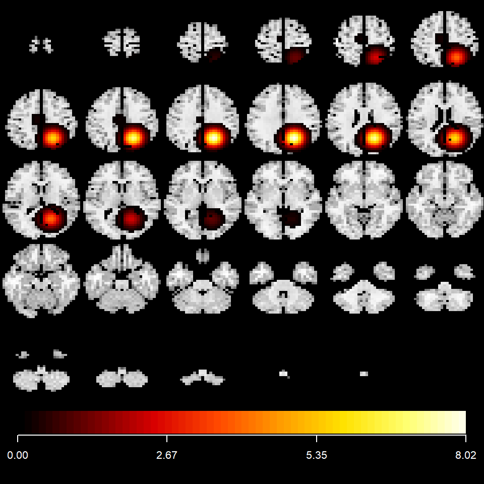

```r
Q = fit113$wbX[[1]][,2]
outstat1 = rec(Q, img1$imagedim, B=B1, mask=img1$brainpos)
outstat2 = -outstat1
coat(template, outstat2)
```

```r
atlastable(tmpatlas, outstat2, atlasdataset)
```

```
## $table
##     ROIid                                                                ROIname sizenum     sizepct     sumvalue Min. 1st Qu. Median         Mean 3rd Qu.         Max.
## 1       1                                                  Left Precentral gyrus      60 0.319148936 6.385419e-01    0       0      0 1.970808e-05       0 1.433462e-01
## 2       2                                                 Right Precentral gyrus      85 0.467032967 1.926003e+00    0       0      0 5.944455e-05       0 1.679313e-01
## 3       3                               Left Superior frontal gyrus-dorsolateral      39 0.156000000 1.324599e-01    0       0      0 4.088268e-06       0 1.744149e-02
## 4       4                              Right Superior frontal gyrus-dorsolateral      63 0.257142857 1.351160e+00    0       0      0 4.170248e-05       0 1.497747e-01
## 5       5                                              Left Middle frontal gyrus       0 0.000000000 0.000000e+00    0       0      0 0.000000e+00       0 0.000000e+00
## 6       6                                             Right Middle frontal gyrus       7 0.028112450 1.936774e-02    0       0      0 5.977698e-07       0 1.308377e-02
## 7       7                             Left Inferior frontal gyrus-opercular part       0 0.000000000 0.000000e+00    0       0      0 0.000000e+00       0 0.000000e+00
## 8       8                            Right Inferior frontal gyrus-opercular part       0 0.000000000 0.000000e+00    0       0      0 0.000000e+00       0 0.000000e+00
## 9       9                            Left Inferior frontal gyrus-triangular part       0 0.000000000 0.000000e+00    0       0      0 0.000000e+00       0 0.000000e+00
## 10     10                           Right Inferior frontal gyrus-triangular part       0 0.000000000 0.000000e+00    0       0      0 0.000000e+00       0 0.000000e+00
## 11     11                                                Left IFG pars orbitalis       0 0.000000000 0.000000e+00    0       0      0 0.000000e+00       0 0.000000e+00
## 12     12                                               Right IFG pars orbitalis       0 0.000000000 0.000000e+00    0       0      0 0.000000e+00       0 0.000000e+00
## 13     13                                                Left Rolandic operculum      22 0.392857143 1.231418e+00    0       0      0 3.800674e-05       0 2.863178e-01
```

[output cut: 160 more lines]

The following method can be used to plot the weights of several components simultaneously. It is first reconstructed in three dimensions with the `multirec` function and then plotted with the `multicompplot` function. It is set to display four columns per component.

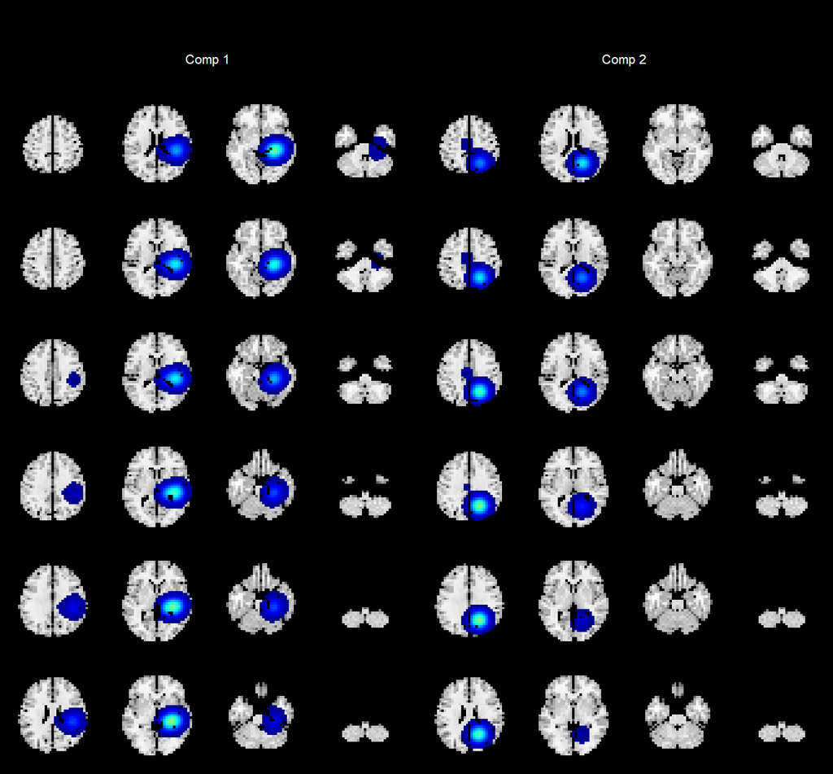

```r
ws = multirec(fit113, imagedim=img1$imagedim, B=B1, mask=img1$brainpos)
multicompplot(ws, template, col4comp=4)
```